# EDA

## Adam Lenning and Sonny George

1. Github = https://github.com/AdamLenning/ArtificialRodrigo

[figure not shown]

3. Name of Project = Artificial Rodrigo
4. See below for EDA

```python
import pandas as pd
import pretty_midi
```

```python
midi_data = pretty_midi.PrettyMIDI('Solo.mid')
midi_list = []

for instrument in midi_data.instruments:
    for note in instrument.notes:
        start = note.start
        end = note.end
        pitch = note.pitch
        velocity = note.velocity
        midi_list.append([start, end, pitch, velocity, instrument.name])

midi_list = sorted(midi_list, key=lambda x: (x[0], x[2]))

df = pd.DataFrame(midi_list, columns=['Start', 'End', 'Pitch', 'Velocity', 'Instrument'])

df['Length'] = df['End'] - df['Start']
df
```

|  | Start | End | Pitch | Velocity | Instrument | Length |
| --- | --- | --- | --- | --- | --- | --- |
| 0 | 2.564749 | 2.689749 | 61 | 51 | Simple Analog Lead | 0.125000 |
| 1 | 2.699641 | 2.835432 | 64 | 55 | Simple Analog Lead | 0.135791 |
| 2 | 2.878598 | 2.968526 | 66 | 55 | Simple Analog Lead | 0.089928 |
| 3 | 3.151080 | 3.375001 | 66 | 22 | Simple Analog Lead | 0.223921 |
| 4 | 3.433454 | 3.572843 | 66 | 72 | Simple Analog Lead | 0.139389 |
| ... | ... | ... | ... | ... | ... | ... |
| 17388 | 3618.969439 | 3619.024295 | 66 | 81 | Simple Analog Lead | 0.054856 |
| 17389 | 3619.009907 | 3619.103432 | 65 | 107 | Simple Analog Lead | 0.093525 |
| 17390 | 3619.094439 | 3619.185267 | 64 | 81 | Simple Analog Lead | 0.090827 |
| 17391 | 3619.177173 | 3619.267101 | 63 | 89 | Simple Analog Lead | 0.089928 |
| 17392 | 3619.267101 | 3620.361527 | 61 | 91 | Simple Analog Lead | 1.094425 |

17393 rows × 6 columns

Our Explanatory Variables are:

Pitch: The pitch of the note. This is represented numerically with each number being a semitone Velocity: Basically the loudness of the note depending on how fast you string the key in the midi controller Length: How long the note is help out for. Is calculated by subtracting the end time from the start time. These aren't beats but rather actual seconds

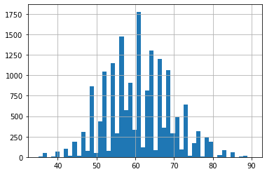

```python
df.Pitch.hist(bins=50)
```

A more interpretable version of pitch is shown below

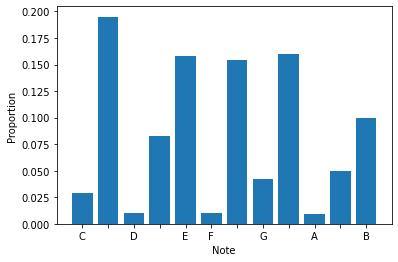

```python
import matplotlib.pyplot as plt
import numpy as np
plt.bar(np.arange(12), midi_data.get_pitch_class_histogram());
plt.xticks(np.arange(12), ['C', '', 'D', '', 'E', 'F', '', 'G', '', 'A', '', 'B'])
plt.xlabel('Note')
plt.ylabel('Proportion')
```

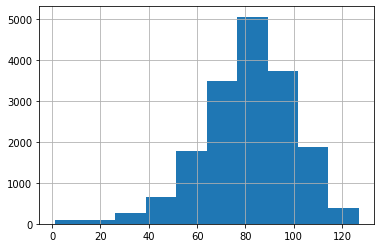

```python
df.Velocity.hist()
```

```
(0.0, 0.5)
```

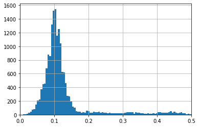

```python
ax = df.Length.hist(bins=1000)
ax.set_xlim(0,0.5)
```

Print the summary Statistics for the 3 numeric variables

```python
# Get the mean length, velocity, and pitch of each instrument
df.groupby('Instrument').agg({'Length': ['mean', 'std'], 'Velocity': ['mean', 'std'], 'Pitch': ['mean', 'std']})
```

| Instrument | Length mean | Length std | Velocity mean | Velocity std | Pitch mean | Pitch std |
| --- | --- | --- | --- | --- | --- | --- |
| Simple Analog Lead | 0.144351 | 0.163505 | 81.028747 | 18.990062 | 60.81872 | 8.473264 |

Find the most common pairings of notes to see what is likely to follow a note, since music data is all correlated and heavily dependent on the previous note. It looks like whole note steps are the most common pairings of notes. This might not be very useful for creating good sounding music.

```python
import nltk

next_notes = list(nltk.bigrams(df['Pitch'].values))

nltk.FreqDist(next_notes).most_common(10)
```

```
[((64, 61), 385),
 ((66, 64), 350),
 ((64, 66), 319),
 ((56, 54), 277),
 ((54, 52), 275),
 ((52, 54), 271),
 ((61, 59), 265),
 ((61, 56), 262),
 ((61, 64), 251),
 ((59, 56), 239)]
```

Since we are generating music as our output, none of the columns provided make any sense to use as our target variable. We will be using a generative model for our output.